# Assessment

Francesca

2024-11-01

## How did antibiotic prescription trends vary pre-, mid-, and post-lockdown in different regions of Scotland?

(Would it be better to focus on the main lockdown (May 2020) or also compare between lockdowns?)

First I will load the appropriate libraries. Then, load, clean and filter the data.

First, I loaded the datasets and created a function to concisely use the same functions on different datasets. I learned how to do this from the website https://www.dataquest.io/blog/write-functions-in-r/. In this function I filtered for antibiotics by only looking at prescriptions with the BNFItemCode starting with 0501. Then I filtered out NAs, cleaned up the names and calculated the number of prescriptions. I then merged the datasets

```r
may2020 <- read_csv(here("data","pitc202005.csv"))
may2024 <- read_csv(here("data","pitc202405.csv"))
may2019 <- read_csv(here("data","pitc201905.csv"))

may2019 <- may2019 %>%
  rename("HBT" = HBT2014)

process_antibiotics <- function(data) {
  data %>%
    filter(str_detect(BNFItemCode, "^0501"), !is.na(BNFItemDescription)) %>%
    mutate(BNFItemDescription = str_replace(BNFItemDescription, "_", " "),
           antibiotic_name = str_extract(BNFItemDescription, "^[^ ]+")) %>% #Extracts the first word, which is the antibiotic name
    group_by(antibiotic_name) %>%
    summarise(quantity_sum = sum(PaidQuantity), .groups = "drop") %>%
    arrange(desc(quantity_sum))
}

#I filtered for prescriptions with an item code beginning with 0501 because prescriptions with that item code are antibiotics (Open Prescribing, 2019).

may2019_processed <- process_antibiotics(may2019)
may2020_processed <- process_antibiotics(may2020)
may2024_processed <- process_antibiotics(may2024)
```

I then prepared the data for joining by renaming Fluclox to Flucloxacillin. I then joined the data, and tidied it

```r
may2020_processed <- may2020_processed %>%
  mutate(antibiotic_name = ifelse(antibiotic_name == "FLUCLOX", "FLUCLOXACILLIN", antibiotic_name))

may2019_processed <- may2019_processed %>%
  mutate(antibiotic_name = ifelse(antibiotic_name == "FLUCLOX", "FLUCLOXACILLIN", antibiotic_name))

antibiotics1920 <- full_join(may2019_processed, may2020_processed, by = "antibiotic_name")
antibiotics192024 <- full_join(antibiotics1920, may2024_processed, by = "antibiotic_name")

antibiotics192024 <- antibiotics192024 %>%
  rename(
   "May 2019" = quantity_sum.x,
   "May 2020" = quantity_sum.y,
   "May 2024" = quantity_sum) %>%
  slice(1:10)

antibiotics192024 <- antibiotics192024 %>%
  mutate(antibiotic_name = str_to_sentence(antibiotic_name)) #I changed all the antibiotic names to only have the first letter capitalised. I learnt this from the R help page
```

I created a stacked bar graph to visually compare prescriptions

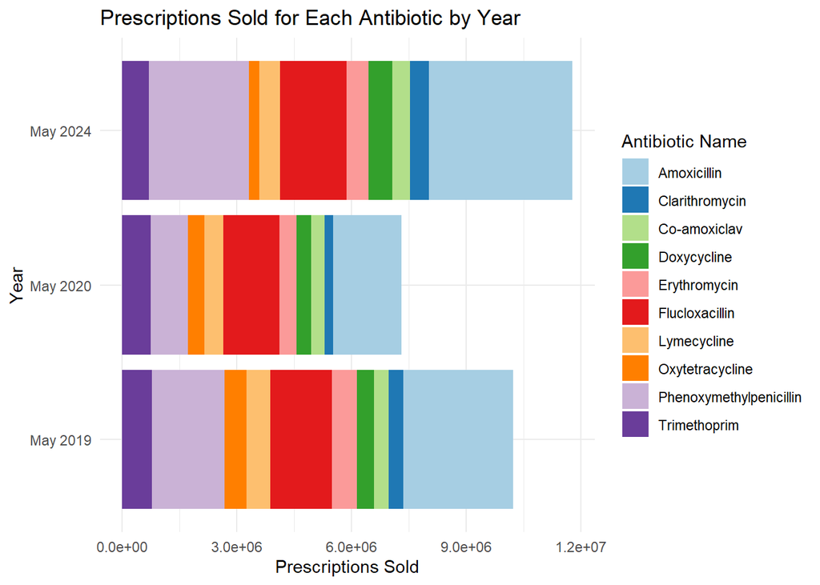

```r
pivoted_antibiotics <- antibiotics192024 %>%
  pivot_longer(
    cols = c("May 2019", "May 2020", "May 2024"),
    names_to = "Year",
    values_to = "Prescription_Number")

antibiotics_graph <- pivoted_antibiotics %>%
  ggplot(aes(x = Prescription_Number, y = Year, fill = antibiotic_name)) +
  geom_bar(stat = "identity") +
  labs(title = "Prescriptions Sold for Each Antibiotic by Year",
       x = "Prescriptions Sold",
       y = "Year",
       fill = "Antibiotic Name") +
  scale_fill_brewer(palette = "Paired") +
  theme_minimal()
antibiotics_graph
```

```r
all_antibiotics_table <- antibiotics192024 %>%
  summarise(across(starts_with("May"), sum, na.rm = TRUE)) %>%
  mutate(antibiotic_name = "Total") %>%
  bind_rows(antibiotics192024, .)

all_antibiotics_table <- all_antibiotics_table %>%
  gt() %>%
  cols_label(antibiotic_name = "Antibiotic") %>%
  cols_align(align = "center",
             columns = everything()) %>%
  tab_style(
    style = cell_text(weight = "bold"),
    locations = cells_column_labels(columns = everything())
  ) %>%
  tab_header(
    title = "Affect of the Covid19 pandemic on the prescription of common antibiotics",
    subtitle = "Looking at the change of prescriptions for the top 10 most common antibiotics from before, during and after the longest Covid19 lockdown") %>%
  tab_spanner(
    label = "Number of Prescriptions",
    columns = c("May 2019", "May 2020", "May 2024"))
all_antibiotics_table
```

Affect of the Covid19 pandemic on the prescription of common antibiotics

Looking at the change of prescriptions for the top 10 most common antibiotics from before, during and after the longest Covid19 lockdown

| Antibiotic | Number of Prescriptions May 2019 | Number of Prescriptions May 2020 | Number of Prescriptions May 2024 |
| --- | --- | --- | --- |
| Amoxicillin | 2875868 | 1778491.0 | 3751932.0 |
| Phenoxymethylpenicillin | 1892108 | 968754.0 | 2616743.0 |
| Flucloxacillin | 1612959 | 1475567.0 | 1733244.0 |
| Trimethoprim | 782422 | 745904.0 | 696670.0 |
| Erythromycin | 661545 | 443204.0 | 582068.0 |
| Lymecycline | 623567 | 493844.0 | 538300.0 |
| Oxytetracycline | 572089 | 428371.0 | 277441.0 |
| Doxycycline | 447389 | 387163.0 | 616170.0 |
| Co-amoxiclav | 382770 | 349958.0 | 466694.0 |
| Clarithromycin | 377144 | 230282.1 | 493464.5 |
| Total | 10227861 | 7301538.1 | 11772726.5 |